# What they have learned?

Przemyslaw Biecek, Anna Kozak

First created on May 20, 2018. Updated on Nov 08, 2020

# 1 Introduction

DALEX explainers may be used to see what type of relation the model can learn / what the model has learned.

If we know the ground truth then we may verify model capability of learning particular types of relations.

# 2 Simulated data

$$(2x_1-1)^2 + sin(10 x_2) + x_3^{6} + (2 x_4 - 1) + |2x_5-1|$$

```r
set.seed(13)
N <- 250
X1 <- runif(N)
X2 <- runif(N)
X3 <- runif(N)
X4 <- runif(N)
X5 <- runif(N)

f <- function(x1, x2, x3, x4, x5) {
  ((x1-0.5)*2)^2-0.5 + sin(x2*10) + x3^6 + (x4-0.5)*2 + abs(2*x5-1)
}
y <- f(X1, X2, X3, X4, X5)
```

# 3 Model fits

```r
library(randomForest)
library(DALEX)
library(e1071)
library(rms)

df <- data.frame(y, X1, X2, X3, X4, X5)

model_rf <- randomForest(y~., df)
model_svm <- svm(y ~ ., df)
model_lm <- lm(y ~ ., df)

# thanks to https://github.com/pbiecek/DALEX/issues/24
## important setup step required for use of rms functions
dd <- datadist(df)
options(datadist="dd")
## add rcs terms to linear model
## this is a very convenient, objective way to account for non-linearity
## still a "linear" model because terms are linear combinations (additive)
model_rms <- ols(y ~ rcs(X1) + rcs(X2) + rcs(X3) + rcs(X4) + rcs(X5), df)

ex_rf <- explain(model_rf, data = df, y = df$y)
ex_svm <- explain(model_svm, data = df, y = df$y)
ex_lm <- explain(model_lm, data = df, y = df$y)
ex_rms <- explain(model_rms, label = "rms", data = df, y = df$y)
ex_tr <- explain(NULL, data = df[,-1],
                 predict_function = function(m, x) f(x[,1], x[,2], x[,3], x[,4], x[,5]),
                 label = "True Model")
```

# 4 Explainers

For `X1` we want to see `(2*x1 - 1)^2`.

The linear model cannot guess the relation without prior preprocessing, the random forest is seeing something but the closest bet is from svm models.

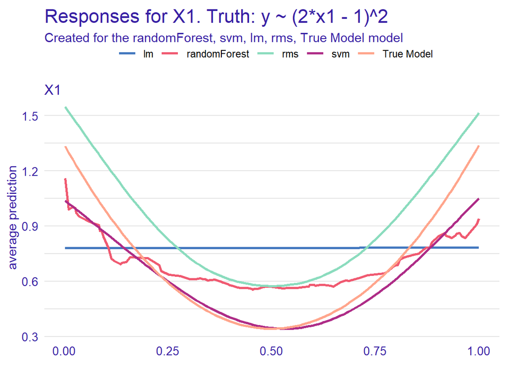

```r
library(ggplot2)
plot(model_profile(ex_rf, "X1"),
     model_profile(ex_svm, "X1"),
     model_profile(ex_lm, "X1"),
     model_profile(ex_rms, "X1"),
     model_profile(ex_tr, "X1")) +
  ggtitle("Responses for X1. Truth: y ~ (2*x1 - 1)^2")
```

For `X2` we want to see `sin(10 * x2)`.

The random forest guesses the shape, svm is not that elastic, the linear model does not see anything.

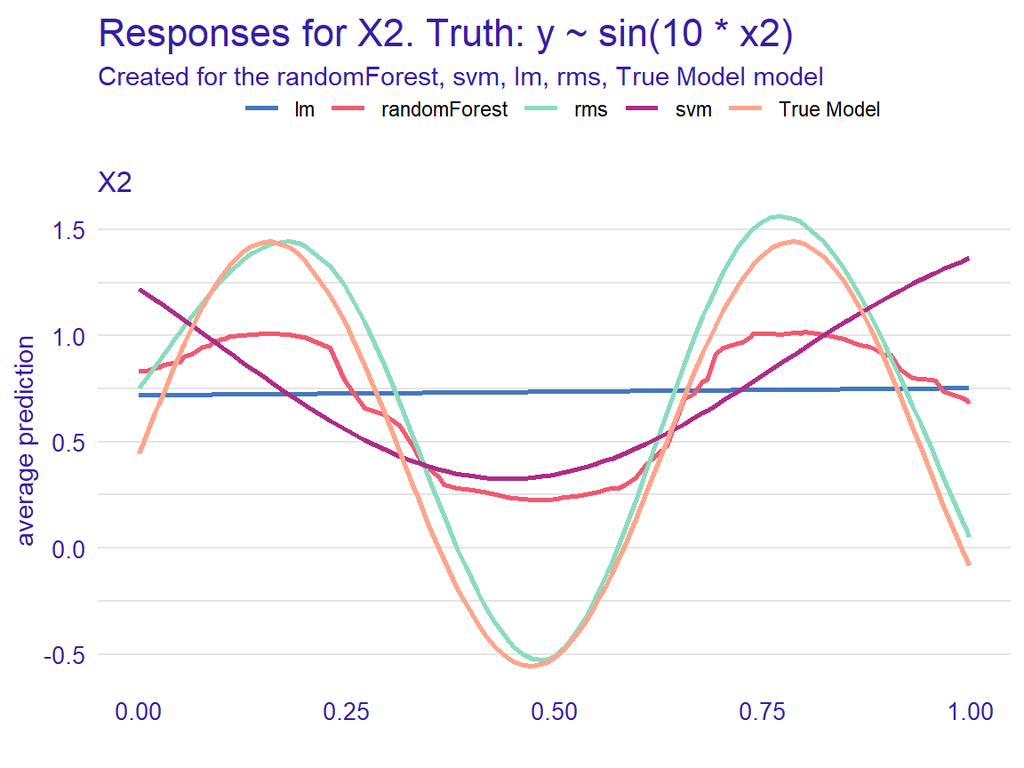

```r
plot(model_profile(ex_rf, "X2"),
     model_profile(ex_svm, "X2"),
     model_profile(ex_lm, "X2"),
     model_profile(ex_rms, "X2"),
     model_profile(ex_tr, "X2")) +
  ggtitle("Responses for X2. Truth: y ~ sin(10 * x2)")
```

For `X3` we want to see `x3^6`.

The random forest is still able to guesses the shape, svm and linear are close.

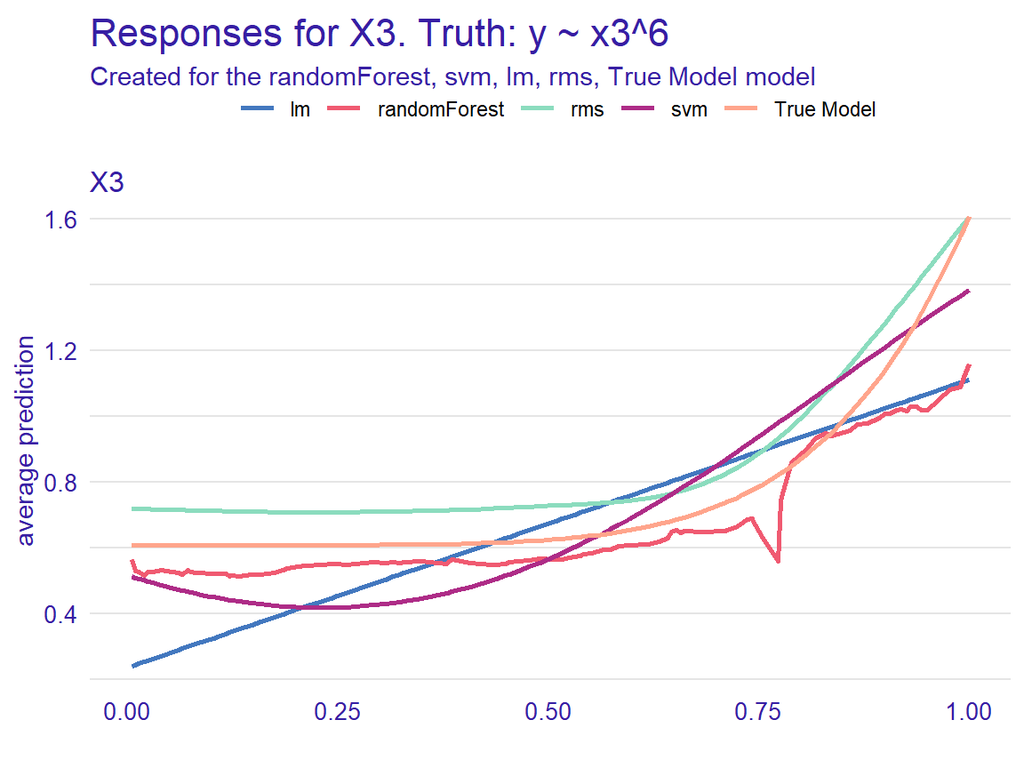

```r
plot(model_profile(ex_rf, "X3"),
     model_profile(ex_svm, "X3"),
     model_profile(ex_lm, "X3"),
     model_profile(ex_rms, "X3"),
     model_profile(ex_tr, "X3")) +
  ggtitle("Responses for X3. Truth: y ~ x3^6")
```

For `X4` we want to see `2 x4 - 1`.

The linear model is doing the best job (as expected), svm are still pretty good, random forest model is more biased towards the mean.

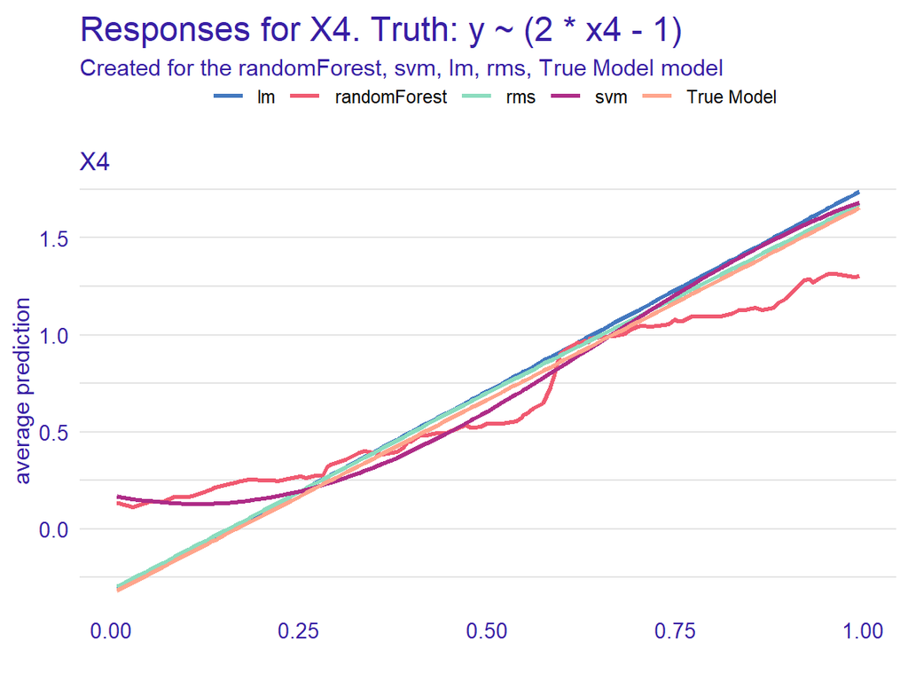

```r
plot(model_profile(ex_rf, "X4"),
     model_profile(ex_svm, "X4"),
     model_profile(ex_lm, "X4"),
     model_profile(ex_rms, "X4"),
     model_profile(ex_tr, "X4")) +
  ggtitle("Responses for X4. Truth: y ~ (2 * x4 - 1)")
```

For `X5` we want to see `|2 x5 - 1|`.

All models except the linear one are guessing the shape.

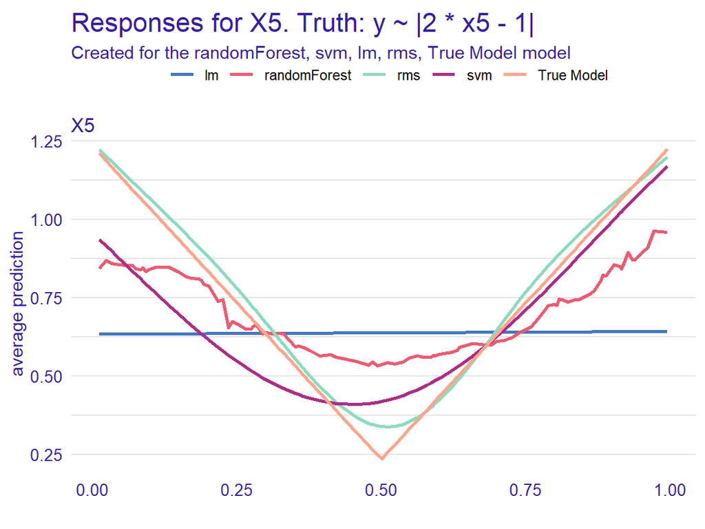

```r
plot(model_profile(ex_rf, "X5"),
     model_profile(ex_svm, "X5"),
     model_profile(ex_lm, "X5"),
     model_profile(ex_rms, "X5"),
     model_profile(ex_tr, "X5")) +
  ggtitle("Responses for X5. Truth: y ~ |2 * x5 - 1|")
```